# Methods 4 – Portfolio Assignment 2

## Task 4: Messing it up

- Try and **deliberately have an open back door path** and see if you can get wrong inference.

```r
# B ~ M + D
mB_MD <- quap(
  alist(
    B ~ dnorm(mu, sigma),
    mu <- a + bM*M + bD*D,
    a ~ dnorm(0, 0.2),
    bM ~ dnorm(0, 0.5),
    bD ~ dnorm(0, 0.5),
    sigma ~ dexp(1)
  ), data = d_sim
)

# B ~ M + D + P
mB_MDP <- quap(
  alist(
    B ~ dnorm(mu, sigma),
    mu <- a + bM*M + bD*D + bP*P,
    a ~ dnorm(0, 0.2),
    bM ~ dnorm(0, 0.5),
    bD ~ dnorm(0, 0.5),
    bP ~ dnorm(0, 0.5),
    sigma ~ dexp(1)
  ), data = d_sim
)


precis(mB_MD)
```

|  | mean | sd | 5.5% | 94.5% |
| --- | --- | --- | --- | --- |
| a | 0.05 | 0.07 | -0.06 | 0.15 |
| bM | 1.45 | 0.08 | 1.32 | 1.58 |
| bD | 1.20 | 0.05 | 1.11 | 1.28 |
| sigma | 1.22 | 0.05 | 1.14 | 1.30 |

```r
precis(mB_MDP)
```

|  | mean | sd | 5.5% | 94.5% |
| --- | --- | --- | --- | --- |
| a | 0.02 | 0.05 | -0.07 | 0.10 |
| bM | 1.06 | 0.07 | 0.95 | 1.17 |
| bD | 0.98 | 0.04 | 0.90 | 1.05 |
| bP | 0.98 | 0.07 | 0.87 | 1.09 |
| sigma | 0.96 | 0.04 | 0.89 | 1.02 |

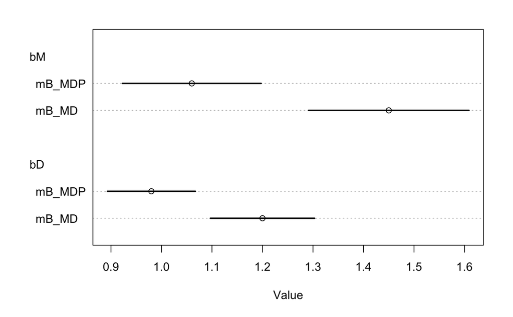

```r
coeftab_plot(coeftab(mB_MD, mB_MDP), pars = c("bM", "bD"))
```

Our DAG tells us that we must stratify by P when modelling the effect of M on B to avoid a backdoor path. We tested this with two models; one including P and one without P. We see that the slopes for both M and D decrease when including P, so not including P will lead us to false inference about M and D’s effect on B.

- Try and deliberately **simulate some data that doesn't fit the DAG**, or **create a new DAG that doesn't fit the data**.

We’ve chosen to create a new DAG and test this on our data. The new, fake DAG is identical to the real one except that we’ve removed the arrow from P to M. The real and fake DAGs are visualised below:

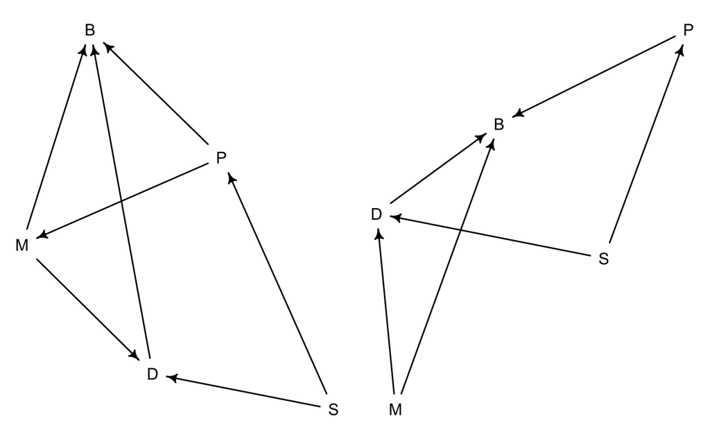

```r
# real DAG (left)
DAG <- dagitty("dag {
D <- S -> P
P -> M -> D -> B
P -> B <- M
}")
# fake DAG (right)
DAG_fake <- dagitty("dag {
D <- S -> P
M -> D -> B
P -> B <- M
}")
DAGs <- list(DAG, DAG_fake)
drawdag(DAGs)
```

These are the implied conditional independencies we get from our two DAGs:

```r
print("Conditional Independencies for the REAL DAG:")
```

```
[1] "Conditional Independencies for the REAL DAG:"
```

```r
print(impliedConditionalIndependencies(DAG))
```

```
B _||_ S | D, M, P
D _||_ P | M, S
M _||_ S | P
```

```r
print("Conditional Independencies for the FAKE DAG:")
```

```
[1] "Conditional Independencies for the FAKE DAG:"
```

```r
impliedConditionalIndependencies(DAG_fake)
```

```
B _||_ S | D, M, P
D _||_ P | S
M _||_ P
M _||_ S
```

- Use the same approach as above to **show that the DAG is wrong** (by showing that conditional independencies don't exist in the data, for example).

We get the following three conditional independencies from our FAKE DAG that are NOT a part of the REAL DAG that we used for simulating our data. D *||* P | S M *||* P M *||* S

[output not shown]

## Peter's perfectly optimal and extremely interesting example

*In a galaxy far, far away...*

*It is a period of civil wars in the galaxy. A brave alliance of underground freedom fighters has challenged the tyranny and oppression of the awesome GALACTIC EMPIRE.*

*To crush the rebellion once and for all, the EMPIRE is constructing a sinister new battle station. Powerful enough to destroy an entire planet, its completion spells certain doom for the champions of freedom.*

*The evil Emperor has figured out, however, that neither the battle station nor the Force can help him avoid that more solar systems join the rebellion. He has therefore hired a CogSci student to use causal modelling and multiple linear regressions to investigate how the activity of the Death Star and other factors affects the probability that a given solar system will join the rebellion (this allows him to more optimally suppress freedom in the Galaxy).*

*You are that student.*

We assume that the probability of a solar system joining the rebellion depends on  
- how many rebellion sympathizers there is in the system (more rebels -> higher probability of joining the rebellion)  
- how scared people are in the system (more scared -> lower probability of joining the rebellion).

How many rebellion sympathizers there is in a system depends on

- crime levels (less crime -> less rebellion sympathizers)

- number of planets recently destroyed by the Death Star (more planets destroyed -> more rebellion sympathizers)

- number of Jedis in the system (more Jedis -> more rebellion sympathizers)

How scared people are depends on

- whether or not the Death Star is nearby (nearby -> more scared)

- how many jedis are in the system (more Jedis -> less scared)

- how much time Darth Vader has spent in the system recently (more time -> more scared)

Crime levels depend on

- number of planets recently destroyed by the Death Star (more planets destroyed -> less crime)

And so on.…